# Joint analysis for Spatial-Mux-seq

## 0.3 Multi-omics integration

```r
############## Basic settings
threads = 8
addArchRThreads(threads = threads)
addArchRGenome("mm10")

samplepath_list <- c('/mnt/HDD1/Users/liran/02_nano_review/17nanobody_deep_ori/Spnanob17_h3k27me3_deep/Save-inTissue-Spananob17_H3K27me3/',
                     '/mnt/HDD1/Users/liran/02_nano_review/17nanobody_deep_ori/Spnanob17_h3k27ac_deep/Save-inTissue-Spananob17_H3K27ac/')
modalitylist <- c('BC6_h3k27me3', 'BC7_h3k27ac')
colnameslist<-c('Spananob17_H3K27me3#','Spananob17_H3K27ac#')

for (i in c('combine_plot')){
  folder_path <- paste0("./",i)
  # Create the new folder
  dir.create(folder_path)
}

################ Call peaks through archR and create the seurat object
for (i in 1:2){
  samplepath <- samplepath_list[i]
  modality <- modalitylist[i]
  colname <- colnameslist[i]
  projCUTA <- loadArchRProject(path = samplepath, force = FALSE, showLogo = TRUE)

  projCUTA <- addGroupCoverages(ArchRProj = projCUTA, groupBy = "Clusters")
  pathToMacs2 <- '/home/liran/miniconda3/envs/macs2/bin/macs2'
  projCUTA <- addReproduciblePeakSet(
    ArchRProj = projCUTA,
    groupBy = "Clusters",
    pathToMacs2 = pathToMacs2,
    force = TRUE
  )

  projCUTA <- addPeakMatrix(projCUTA)

  PeakSet <- getPeakSet(projCUTA)
  SummarizedExperiment<- getMatrixFromProject( ArchRProj = projCUTA, useMatrix = "PeakMatrix")
  SummarizedExperiment_assay <- assay(SummarizedExperiment)

  # Combine seqnames and ranges into column names
  col_names <- paste(seqnames(PeakSet), ranges(PeakSet), sep = "-")
  # Set the column names of the sparse matrix
  rownames(SummarizedExperiment_assay) <- col_names

  colnames_sparse <- colnames(SummarizedExperiment_assay)
  new_colnames <- sub(colname, "", colnames_sparse)
  new_colnames <- sub("-1", "", new_colnames)
  colnames(SummarizedExperiment_assay) <-new_colnames
  if(i == 1){
    seurat.wnn.peak <- CreateSeuratObject(counts = SummarizedExperiment_assay, assay = paste0('peaks_',modality))
  } else {
    # create a new assay to store ADT information
    adt_assay <- CreateAssayObject(counts = SummarizedExperiment_assay)
    adt_assay <- subset(adt_assay, cells = colnames(seurat.wnn.peak[[paste0('peaks_',modalitylist[1])]]))
    # add this assay to the previously created Seurat object
    seurat.wnn.peak[[paste0('peaks_',modality)]] <- adt_assay
  }

}

########### Multi-omics integration through WNN
for(x in modalitylist){
  DefaultAssay(seurat.wnn.peak) <- paste0('peaks_',x)
  seurat.wnn.peak <- RunTFIDF(seurat.wnn.peak) %>% FindTopFeatures() %>% RunSVD(reduction.name = paste0(x,'_lsi'))
}

seurat.wnn.peak <- FindMultiModalNeighbors(
  seurat.wnn.peak, reduction.list = list( 'BC6_h3k27me3_lsi', 'BC7_h3k27ac_lsi'),
  dims.list = list(2:30,2:30), modality.weight.name = "histone.weight",k.nn = 10
)

seurat.wnn.peak <- FindClusters(seurat.wnn.peak, graph.name = "wsnn", algorithm = 3, resolution = 1, verbose = FALSE)


for(x in modalities){
  assay <- paste0('peaks_',x,'.weight')
  p2 <- FeaturePlot(seurat.wnn.peak,assay,min.cutoff = 0.2,max.cutoff = 0.6) + scale_color_viridis_c()
  pdf(paste0("combine_plot/", outputname, '_', x,"_clusters_umap_wsnn_weight.pdf"), width = 5, height = 5)
  print(p2)
  dev.off()
}

n_clusters <- length(unique(seurat.wnn.peak$wsnn_res.1))
cols <- ArchRPalettes$stallion[as.character(seq_len(n_clusters))]
names(cols) <- paste0( seq_len(n_clusters)-1)
cols

p3 <- DimPlot(seurat.wnn.peak,label=TRUE,pt.size=0.5, cols = cols)

pdf(paste0("combine_plot/", outputname, "_clusters_umap_wsnn_res.1.pdf"), width = 5.3, height = 4)
print(p3)
dev.off()

p3
```

You can also visualize the spatial plot.

```r
## add image, use any path to spatial folder
data.dir <- "/mnt/HDD1/Users/liran/02_nano_review/17nanobody_deep/generate_RMD/Spananob17_H3K27me3/"
filter.matrix = TRUE
image <- Read10X_Image(image.dir = file.path(data.dir, "spatial"), filter.matrix = filter.matrix)
image <- image[sub("-1", "", sub("Spananob18_BC5#", "", Cells(x = seurat.wnn.peak)))]
DefaultAssay(seurat.wnn.peak = image) <- 'peaks_BC7_h3k27ac'
slice = "slice1"
seurat.wnn.peak[[slice]] <- image


# spatial plot weight cluster
for(x in modalities){
  assay <- paste0('peaks_',x,'.weight')

  p3 <- SpatialPlot(seurat.wnn.peak, label = FALSE, label.size = 3, features = assay,pt.size.factor = 4.5,  image.alpha = 0, stroke = 0, min.cutoff = 0.3, max.cutoff = 0.9)+ scale_color_viridis_c()
  p3$layers[[1]]$aes_params <- c(p3$layers[[1]]$aes_params, shape=22)

  pdf(paste0("combine_plot/", outputname, '_', x,"_clusters_spatial_wsnn_weight.pdf"), width = 5, height = 5)
  print(p3)
  dev.off()
}


# spatial plot cluster
p4 <- SpatialPlot(seurat.wnn.peak, label = FALSE, label.size = 3, group.by = 'wsnn_res.1', pt.size.factor = 4.5, cols = cols, image.alpha = 0, stroke = 0)
p4$layers[[1]]$aes_params <- c(p4$layers[[1]]$aes_params, shape=22)
p4

pdf(paste0("combine_plot/", outputname, "_clusters_spatial_wsnn_res.1.pdf"), width = 5, height = 5)
print(p4)
dev.off()

# Save the Seurat object to an RDS file
saveRDS(seurat.wnn.peak, file = "./seurat.wnn.peak.rds")

p4
```

To reproduce exact the same results from our paper, we have provided our Seurat object with all omics layers and you can directly load them through the following code.

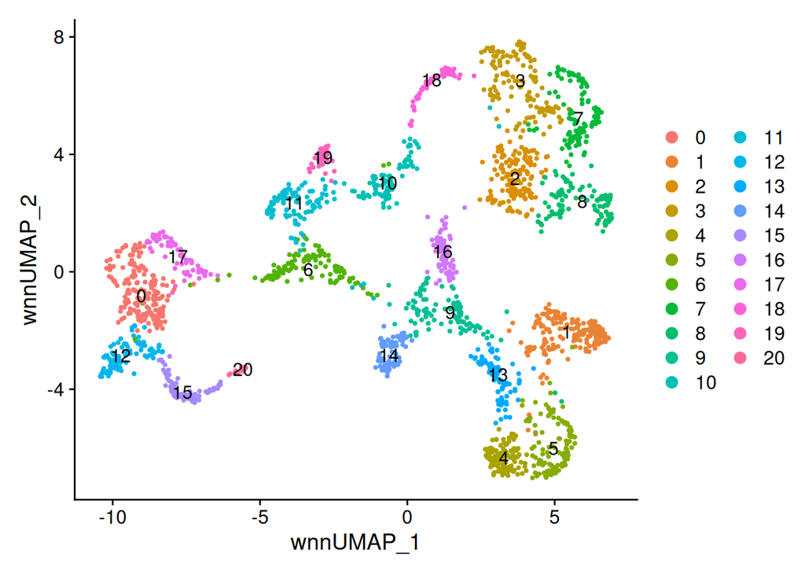

```r
spatial.obj <- readRDS('/mnt/HDD1/Users/liran/02_nano_review/17nanobody_deep/combine_17nanobody_deep/seurat.wnn.peak_upload.rds')

p1 <- DimPlot(spatial.obj, reduction = "wnn.umap", label = TRUE)
p1
```

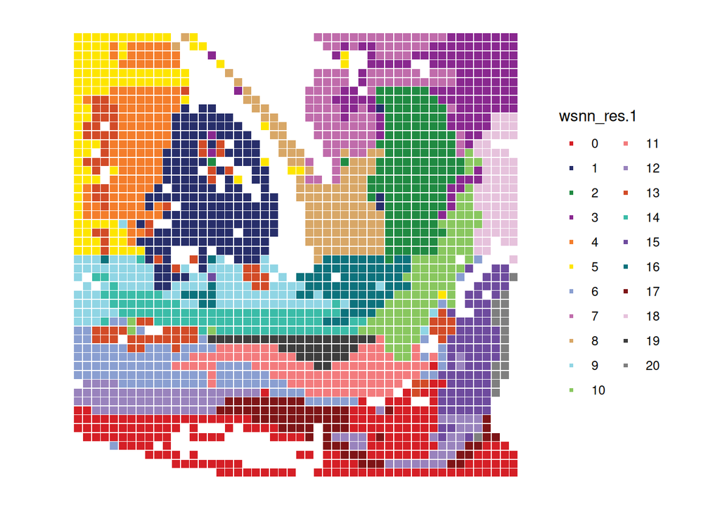

```r
n_clusters <- length(unique(spatial.obj$wsnn_res.1))
cols <- ArchRPalettes$stallion[as.character(seq_len(n_clusters))]
names(cols) <- paste0( seq_len(n_clusters)-1)

p1 <- SpatialPlot(spatial.obj, label = FALSE, label.size = 3, group.by = 'wsnn_res.1', pt.size.factor = 5, cols = cols,  image.alpha = 0, stroke = 0)
p1$layers[[1]]$aes_params <- c(p1$layers[[1]]$aes_params, shape=22)
p1
```

**R version 4.4.1 (2024-06-14)**

**Platform:** x86_64-pc-linux-gnu

**locale:** *LC_CTYPE=en_US.UTF-8*, *LC_NUMERIC=C*, *LC_TIME=en_US.UTF-8*, *LC_COLLATE=en_US.UTF-8*, *LC_MONETARY=en_US.UTF-8*, *LC_MESSAGES=en_US.UTF-8*, *LC_PAPER=en_US.UTF-8*, *LC_NAME=C*, *LC_ADDRESS=C*, *LC_TELEPHONE=C*, *LC_MEASUREMENT=en_US.UTF-8* and *LC_IDENTIFICATION=C*

**attached base packages:** *stats4*, *grid*, *stats*, *graphics*, *grDevices*, *utils*, *datasets*, *methods* and *base*

**other attached packages:** *pander(v.0.6.5)*, *dplyr(v.1.1.4)*, *patchwork(v.1.2.0)*, *BSgenome.Mmusculus.UCSC.mm10(v.1.4.3)*, *BSgenome(v.1.72.0)*, *rtracklayer(v.1.64.0)*, *BiocIO(v.1.14.0)*, *Biostrings(v.2.72.1)*, *XVector(v.0.44.0)*, *SeuratObject(v.4.1.4)*, *Seurat(v.4.4.0)*, *rhdf5(v.2.48.0)*, *SummarizedExperiment(v.1.34.0)*, *Biobase(v.2.64.0)*, *MatrixGenerics(v.1.16.0)*, *Rcpp(v.1.0.12)*, *Matrix(v.1.7-0)*, *GenomicRanges(v.1.56.1)*, *GenomeInfoDb(v.1.40.1)*, *IRanges(v.2.38.0)*, *S4Vectors(v.0.42.0)*, *BiocGenerics(v.0.50.0)*, *matrixStats(v.1.3.0)*, *data.table(v.1.15.4)*, *stringr(v.1.5.1)*, *plyr(v.1.8.9)*, *magrittr(v.2.0.3)*, *ggplot2(v.3.5.1)*, *gtable(v.0.3.5)*, *gtools(v.3.9.5)*, *gridExtra(v.2.3)* and *ArchR(v.1.0.2)*

**loaded via a namespace (and not attached):** *RColorBrewer(v.1.1-3)*, *rstudioapi(v.0.16.0)*, *jsonlite(v.1.8.8)*, *spatstat.utils(v.3.0-5)*, *rmarkdown(v.2.27)*, *zlibbioc(v.1.50.0)*, *vctrs(v.0.6.5)*, *ROCR(v.1.0-11)*, *Rsamtools(v.2.20.0)*, *spatstat.explore(v.3.2-7)*, *RCurl(v.1.98-1.14)*, *htmltools(v.0.5.8.1)*, *S4Arrays(v.1.4.1)*, *curl(v.5.2.1)*, *Rhdf5lib(v.1.26.0)*, *SparseArray(v.1.4.8)*, *sass(v.0.4.9)*, *sctransform(v.0.4.1)*, *parallelly(v.1.37.1)*, *KernSmooth(v.2.23-24)*, *bslib(v.0.7.0)*, *htmlwidgets(v.1.6.4)*, *ica(v.1.0-3)*, *plotly(v.4.10.4)*, *zoo(v.1.8-12)*, *cachem(v.1.1.0)*, *GenomicAlignments(v.1.40.0)*, *igraph(v.2.0.3)*, *mime(v.0.12)*, *lifecycle(v.1.0.4)*, *pkgconfig(v.2.0.3)*, *R6(v.2.5.1)*, *fastmap(v.1.2.0)*, *GenomeInfoDbData(v.1.2.12)*, *fitdistrplus(v.1.1-11)*, *future(v.1.33.2)*, *shiny(v.1.8.1.1)*, *digest(v.0.6.36)*, *colorspace(v.2.1-0)*, *tensor(v.1.5)*, *irlba(v.2.3.5.1)*, *progressr(v.0.14.0)*, *fansi(v.1.0.6)*, *spatstat.sparse(v.3.1-0)*, *polyclip(v.1.10-6)*, *httr(v.1.4.7)*, *abind(v.1.4-5)*, *compiler(v.4.4.1)*, *withr(v.3.0.0)*, *BiocParallel(v.1.38.0)*, *MASS(v.7.3-61)*, *DelayedArray(v.0.30.1)*, *rjson(v.0.2.21)*, *tools(v.4.4.1)*, *lmtest(v.0.9-40)*, *httpuv(v.1.6.15)*, *future.apply(v.1.11.2)*, *goftest(v.1.2-3)*, *glue(v.1.7.0)*, *restfulr(v.0.0.15)*, *nlme(v.3.1-165)*, *rhdf5filters(v.1.16.0)*, *promises(v.1.3.0)*, *Rtsne(v.0.17)*, *cluster(v.2.1.6)*, *reshape2(v.1.4.4)*, *generics(v.0.1.3)*, *spatstat.data(v.3.1-2)*, *tidyr(v.1.3.1)*, *sp(v.2.1-4)*, *utf8(v.1.2.4)*, *spatstat.geom(v.3.2-9)*, *RcppAnnoy(v.0.0.22)*, *ggrepel(v.0.9.5)*, *RANN(v.2.6.1)*, *pillar(v.1.9.0)*, *later(v.1.3.2)*, *splines(v.4.4.1)*, *lattice(v.0.22-5)*, *deldir(v.2.0-4)*, *survival(v.3.7-0)*, *tidyselect(v.1.2.1)*, *miniUI(v.0.1.1.1)*, *pbapply(v.1.7-2)*, *knitr(v.1.47)*, *scattermore(v.1.2)*, *xfun(v.0.45)*, *stringi(v.1.8.4)*, *UCSC.utils(v.1.0.0)*, *lazyeval(v.0.2.2)*, *yaml(v.2.3.8)*, *evaluate(v.0.24.0)*, *codetools(v.0.2-20)*, *tibble(v.3.2.1)*, *cli(v.3.6.3)*, *uwot(v.0.2.2)*, *xtable(v.1.8-4)*, *reticulate(v.1.38.0)*, *munsell(v.0.5.1)*, *jquerylib(v.0.1.4)*, *spatstat.random(v.3.2-3)*, *globals(v.0.16.3)*, *png(v.0.1-8)*, *XML(v.3.99-0.17)*, *parallel(v.4.4.1)*, *bitops(v.1.0-7)*, *listenv(v.0.9.1)*, *viridisLite(v.0.4.2)*, *scales(v.1.3.0)*, *ggridges(v.0.5.6)*, *leiden(v.0.4.3.1)*, *purrr(v.1.0.2)*, *crayon(v.1.5.3)*, *rlang(v.1.1.4)* and *cowplot(v.1.1.3)*